# HomeExam_YardenViktorDejorno_313251886

## first page

```python
# %pip install seaborn
from scipy import stats
import pandas as pd
import numpy as np
import seaborn as sns
import matplotlib.pyplot as plt
```

### Download Credit data set.

#### Answer:

```python
db = pd.read_csv('Credit.csv')
db["Own"] = db["Own"].map({"Yes": 1, "No": 0})
db["Student"] = db["Student"].map({"Yes": 1, "No": 0})
db["Married"] = db["Married"].map({"Yes": 1, "No": 0})
```

### Calculate correlation heatmap for each value of “Region” variable separately.

#### Answer:

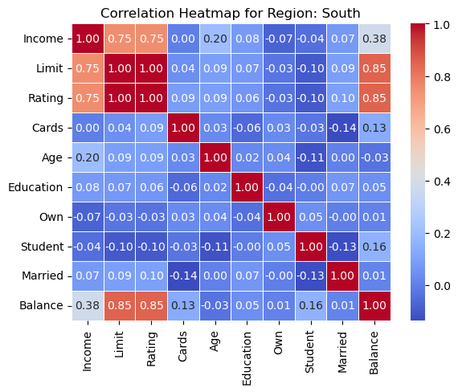

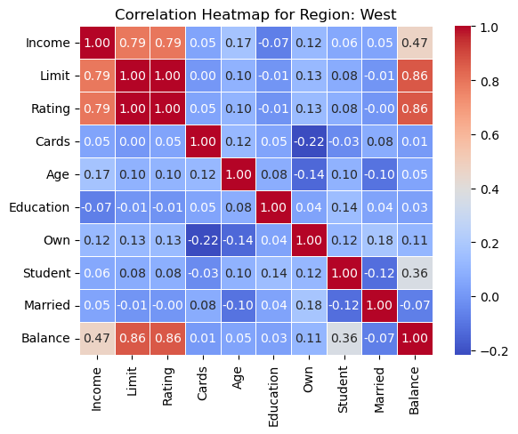

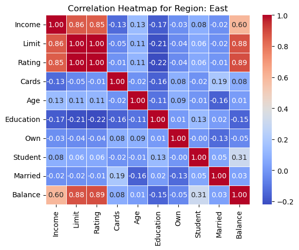

```python
for Region in  pd.unique(db['Region']):
	df=db[db['Region']==Region].drop(columns=["Region"])
	corr_matrix = df.corr()
	sns.heatmap(corr_matrix, annot=True, cmap="coolwarm", fmt=".2f", linewidths=0.5)
	plt.title(f"Correlation Heatmap for Region: {Region}")
	plt.savefig(f"Credit_corr_matrix_{Region}.png")
	plt.show()
```

### What can you learn from the heat map?

#### Answer:

First, a complete positive correlation exists between a person's rating and limit.  
Income is correlated with rating and limit across all regions  
Income seems to correlate more with rating and limit in the east than in the south.  
In the east, a weak negative correlation exists between education to limit and rating.  
In the west, there is a weak negative correlation between Own and Cards.

### Plot a box plot of the “Income” variable for each value of the variable “Cards”.

#### Answer:

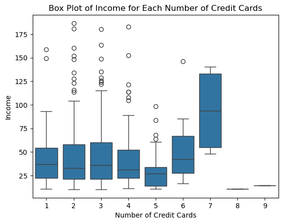

```python
sns.boxplot(x = db['Cards'],y = db['Income'] )
plt.xlabel("Number of Credit Cards")
plt.ylabel("Income")
plt.title("Box Plot of Income for Each Number of Credit Cards")
plt.savefig(f"Income for Each Number of Credit Cards.png")
plt.show()
```

## second page

#### Suppose a store has three types of customers:

##### Regular customers (60%)

##### Premium customers (30%)

##### VIP customers (10%)

#### The probability that a customer makes a purchase given their category is:

##### Regular: 0.4

##### Premium: 0.7

##### VIP: 0.9

### What is the overall probability that a randomly chosen customer makes a purchase?

#### Answer:

$$ P[Buy == 1] = P[Buy|Regular] * P[Regular] + P[Buy|Premium] * P[Premium] + P[Buy|VIP] * P[VIP] $$

```python
P_R = 0.60
P_P = 0.30
P_V = 0.10
P_B_R = 0.4
P_B_P = 0.7
P_B_V = 0.9

P_B = (P_B_R * P_R) + (P_B_P * P_P) + (P_B_V * P_V)
print(f"{round(P_B*100,2)}%")
```

```
54.0%
```

## Third page

#### A bank is assessing whether a loan applicant will default on their loan. Based on historical data:

##### 5% of all loan applicants default on their loans.

##### 80% of those who defaulted had a low credit score.

##### 30% of all applicants have a low credit score.

### If a randomly chosen applicant has a low credit score, what is the probability that they will default?

#### Answer:

$$ P[default == 1 ] = 0.05 $$ $$ P[LowCreditScore| default] = 0.8 $$ $$ P[LowCreditScore] = 0.3 $$ $$ P[default|LowCreditScore] = ? $$

Base Law : $$ P(A | B) = \frac{P(B | A) \cdot P(A)}{P(B)} $$ so : $$ P[default|LowCreditScore] = \frac{P[LowCreditScore| default] \cdot P[default]}{P[LowCreditScore]} = \frac{0.8 \cdot 0.05}{0.3} $$

```python
P_D = 0.05
P_LS = 0.30
P_LS_D = 0.80

P_D_LS = (P_LS_D * P_D) / P_LS
print(f"{round(P_D_LS*100,2)}%")
```

```
13.33%
```

## Fourth page

#### Simulate a $10*1000$ matrix with $x_1, x_2, . . . , x_10 ∼ exp(2) $

#### Calculate a biased and unbiased estimator for $ V ar(X) = \frac {1 } {λ^2} $

#### Average on the results for both methods.

#### Write an expression for the difference.

#### Answer:

```
1.	Population Variance (Biased Estimator)
```

$$ \sigma^2 = \frac{1}{N} \sum_{i=1}^{N} (X_i - \bar{X})^2$$

where N is the sample size.

```
2.	Sample Variance (Unbiased Estimator)
```

$$ S^2 = \frac{1}{N-1} \sum_{i=1}^{N} (X_i - \bar{X})^2$$

```
3.	Difference
```

$$ \frac{N}{N - 1} $$

```python
n = 10
matrix = np.random.exponential(scale=1/2, size=(n, 1000))
Biased = np.sum((matrix - np.mean(matrix)) ** 2 ) / n
unBiased = np.sum((matrix - np.mean(matrix)) ** 2 ) / ( n - 1)
mean_Biased = np.mean(Biased)
mean_unBiased = np.mean(unBiased)
print(f"Mean of Based: {mean_Biased}")
print(f"Mean of UnBiased: {mean_unBiased}")

difference = mean_unBiased / mean_Biased
difference_Theoretical = n / (n - 1)
print(f"Difference: {round(difference,3)}")
print(f"Theoretical Difference: {round(difference_Theoretical,3)}")
```

```
Mean of Based: 241.2061324559242
Mean of UnBiased: 268.0068138399158
Difference: 1.111
Theoretical Difference: 1.111
```

## Fifth page

#### Simulate 1000 samples of size 100 from the exp(3) distribution.

### What is the mean E(X) of exp(3)? What is the variance and sd?

#### Answer:

$$ E[X] = \frac{1}{\lambda} $$

$$ \hat{E[X]} = \bar{X} $$

$$ \text{Var}(X) = \frac{1}{\lambda^2} $$

$$ \hat{\text{Var}}(X) = \frac{1}{\hat{\lambda}^2} = \bar{X}^2 $$

$$ \text{SD}(X) = \sqrt{\text{Var}(X)} = \frac{1}{\lambda} $$

$$ \hat{\lambda} = \frac{1}{\bar{X}} $$

$$ \hat{\text{SD}}(X) = \frac{1}{\hat{\lambda}} = \bar{X} $$

```python
n = 1000
sample_size = 100  # גודל כל דגימה
lambda_val = 3
samples = np.random.exponential(scale=1/lambda_val, size=(n, sample_size))

true_mean = 1 / lambda_val

sample_means = np.mean(samples, axis=1)
mean_of_samples = np.mean(sample_means, axis=0)
print(f"True Mean: {  round(true_mean,4)}")
print(f"Mean of Samples: {  round(mean_of_samples,4) }")
print()
true_variance = 1 / (lambda_val ** 2)
var_samples = mean_of_samples ** 2
print(f"True Variance: {  round(true_variance,4)}")
print(f"Variance from Samples: {  round(var_samples,4)}")
print()
true_sd = np.sqrt(true_variance)
print(f"True Standard Deviation: { round(true_sd,4)}")
sample_sd = mean_of_samples
print(f"Standard Deviation from Samples: {round(sample_sd,4)}")
```

```
True Mean: 0.3333
Mean of Samples: 0.3331

True Variance: 0.1111
Variance from Samples: 0.111

True Standard Deviation: 0.3333
Standard Deviation from Samples: 0.3331
```

### Test the following two sided hypotheses:

$$H0 : µ0 = E[exp(3)]$$ $$ H1 : µ0 \neq E[exp(3)] $$

### Use both methods learned in class.

### Calculate the proportion of times that H0 was rejected.

#### Answer:

##### **ביצוע בדיקת השערות באמצעות ערך קריטי**

נבצע בדיקה על כל הדגימות, ונבדוק בכל פעם האם ממוצע הדגימה חורג מהערך הקריטי ($c$ ). אם כן, נדחה את ($H_0$) י .

##### **ביצוע בדיקת השערות באמצעות $pvalue$ י**

בבדיקה זו, נחשב עבור כל דגימה את **סטטיסטי הבדיקה ($Z$)** ואת **$p-value$** המתאים. אם ה-$p-value$ קטן מרמת המובהקות ($\alpha$), נדחה את ($H_0$) י.

```python
std = np.std(sample_means, ddof=1)   # סטיית תקן
Z = (sample_means - true_mean) / std # Z ערך

# ערך קריטי
Z_critical = stats.t.ppf( 0.975 , df=sample_size - 1) #ערך קריטי
reject_h0_critical = np.abs(Z) > Z_critical
print(f"{round(np.mean(reject_h0_critical)*100,3)}%")

# Pvalue
p_value = (1 - stats.t.cdf(np.abs(Z), df=sample_size - 1))
reject_h0_pval = p_value < 0.05/2
print(f"{round(np.mean(reject_h0_pval)*100,3)}%")
```

```
4.4%
4.4%
```

## sixth page

### Write the pmf of $X_1, . . . , X_n$ given Y.

#### Answer:

$$ P(X_1 = x_1, X_2 = x_2, \dots\space, X_n = x_n \mid Y = y) $$

### Write the pmf if given $Y , X_1, . . . , X_n $ are independent.

#### Answer:

$$ P_{Y, X_1, X_2, \dots, X_n}(y, x_1, x_2, \dots, x_n) = P_Y(y) \cdot P_{X_1}(x_1) \cdot P_{X_2}(x_2) \dots \space \cdot P_{X_n}(x_n) $$

### Write the density of two independent normal variables.

#### Answer:

Density of $X , Y $ if $X , Y $ are normal: $$ f X (x) = \frac{1}{\sqrt{2\pi \sigma_x^2}} \exp \left( -\frac{(x - \mu)^2}{2\sigma_x^2} \right) $$ $$ f Y (y) = \frac{1}{\sqrt{2\pi \sigma_y^2}} \exp \left( -\frac{(y - \mu)^2}{2\sigma_y^2} \right) $$

Joint density: $$ f_{X,Y}(x, y) = f_X(x) \cdot f_Y(y) = \frac{1}{2\pi \sigma_x \sigma_y} \exp \left( -\frac{(x - \mu_x)^2}{2\sigma_x^2} - \frac{(y - \mu_y)^2}{2\sigma_y^2} \right) $$

#### Assume that $X_1, X_2 $ have a multivariate Normal distribution:

$$ \sum = \begin{bmatrix} \sigma ^2 & 0 \\ 0 & \sigma ^2 \end{bmatrix} $$

#### and that

$$ \mu = \begin{bmatrix} 0 \\ 0 \end{bmatrix} $$

### Prove that $X_1$ and $X_2$ are independent.

#### Answer:

the covariance between $X_1$ and $X_2$ is 0 $$ \Sigma_{12} = 0 $$ $$ \Sigma_{21} = 0 $$ So $X_1$ and $X_2$ are independent.